# exploration

Amelia Foley

#Overview This markdown loads processed data and explores relationships among these variables:

- SwollenLymphNodes: yes/no experienced swollen lymph nodes
- ChestCongestion: yes/no experienced chest congestion
- ChillsSweats: yes/no experienced chills or sweats
- Fatigue: yes/no experienced fatigue
- Headache: yes/no experienced headache
- RunnyNose: yes/no experienced runny nose
- Nausea: yes/no experienced nausea
- Pharyngitis: yes/no experienced sore throat
- BodyTemp: numeric, body temperature (F)
- AbPain: yes/no experienced abdominal pain
- NasalCongestion: yes/no experienced nasal congestion

#Main outcomes Main continuous outcome: BodyTemp Main categorical outcome: Nausea

# load packages and data

```r
library(dplyr)
library(tidyverse)
library(here)
library(gtsummary) #for summary table

# set data location
data_location <- data_location <- here::here("data","processed_data","processeddata.rds")
# load data
data <- readRDS(data_location)
```

# view summary statistics for variables of interest

```r
summary(data) %>% print()
```

```
##  SwollenLymphNodes ChestCongestion ChillsSweats NasalCongestion CoughYN
##  No :418           No :323         No :130      No :167         No : 75
##  Yes:312           Yes:407         Yes:600      Yes:563         Yes:655
##
##
##
##
##  Sneeze    Fatigue   SubjectiveFever Headache      Weakness   WeaknessYN
##  No :339   No : 64   No :230         No :115   None    : 49   No : 49
##  Yes:391   Yes:666   Yes:500         Yes:615   Mild    :223   Yes:681
##                                                Moderate:338
##                                                Severe  :120
##
##
##   CoughIntensity CoughYN2      Myalgia    MyalgiaYN RunnyNose AbPain
##  None    : 47    No : 47   None    : 79   No : 79   No :211   No :639
##  Mild    :154    Yes:683   Mild    :213   Yes:651   Yes:519   Yes: 91
##  Moderate:357              Moderate:325
##  Severe  :172              Severe  :113
##
##
##  ChestPain Diarrhea  EyePn     Insomnia  ItchyEye  Nausea    EarPn
##  No :497   No :631   No :617   No :315   No :551   No :475   No :568
##  Yes:233   Yes: 99   Yes:113   Yes:415   Yes:179   Yes:255   Yes:162
##
##
##
##
##  Hearing   Pharyngitis Breathless ToothPn   Vision    Vomit     Wheeze
##  No :700   No :119     No :436    No :565   No :711   No :652   No :510
##  Yes: 30   Yes:611     Yes:294    Yes:165   Yes: 19   Yes: 78   Yes:220
##
##
##
##
##     BodyTemp
##  Min.   : 97.20
##  1st Qu.: 98.20
##  Median : 98.50
##  Mean   : 98.94
##  3rd Qu.: 99.30
##  Max.   :103.10
```

In this summary view, we can see the values for each variables (yes vs no) and the statistics for our one continuous variable, BodyTemp. For our key categorical variable, let’s view our summary statistics as proportions.

# Nausea proportions

```r
table1 <- table(data$Nausea)
prop.table(table1) %>% print()
```

```
##
##        No       Yes
## 0.6506849 0.3493151
```

Significantly more people did NOT experience nausea than did experience nausea.

# make a nicer looking summary table for our variables

```r
table2 <- tbl_summary(data, type = all_categorical() ~ "categorical")
#view table
table2
```

| **Characteristic** | **N = 730**<sup>1</sup> |
| --- | --- |
| SwollenLymphNodes |  |
| No | 418 (57%) |
| Yes | 312 (43%) |
| ChestCongestion |  |
| No | 323 (44%) |
| Yes | 407 (56%) |
| ChillsSweats |  |
| No | 130 (18%) |
| Yes | 600 (82%) |
| NasalCongestion |  |
| No | 167 (23%) |
| Yes | 563 (77%) |
| CoughYN |  |
| No | 75 (10%) |
| Yes | 655 (90%) |
| Sneeze |  |
| No | 339 (46%) |
| Yes | 391 (54%) |
| Fatigue |  |
| No | 64 (8.8%) |
| Yes | 666 (91%) |
| SubjectiveFever |  |
| No | 230 (32%) |
| Yes | 500 (68%) |
| Headache |  |
| No | 115 (16%) |
| Yes | 615 (84%) |
| Weakness |  |
| None | 49 (6.7%) |
| Mild | 223 (31%) |

[output cut: 70 more lines]

<sup>*1*</sup> n (%); Median (IQR)

```r
#save table
saveRDS(table2, file = here("results", "EDA", "summarytable.rds"))
```

# plot for continuous variable (BodyTemp)

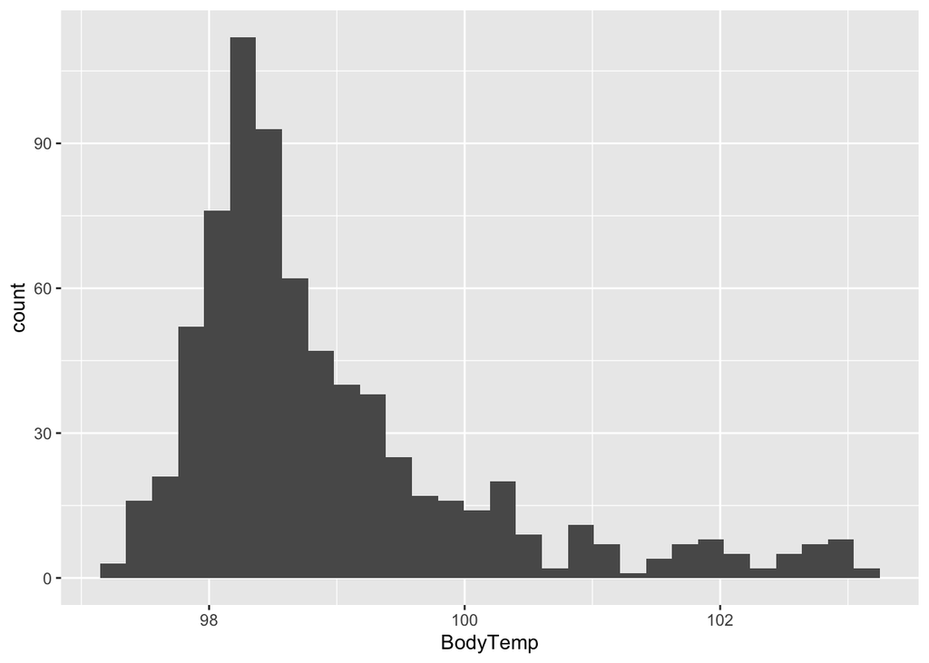

```r
histogram <- data %>% ggplot(aes(BodyTemp)) + geom_histogram(bins = 30)
#save table
saveRDS(histogram, file = here("results", "EDA", "histogrambodytemp.rds"))
#view table
histogram
```

Our summary statistics above tell us that the mean BodyTemp is 98.9. A median of 98.5 and the histogram above tell us that the values range up to 103, relatively high.

# plot for categorical outcome of interest

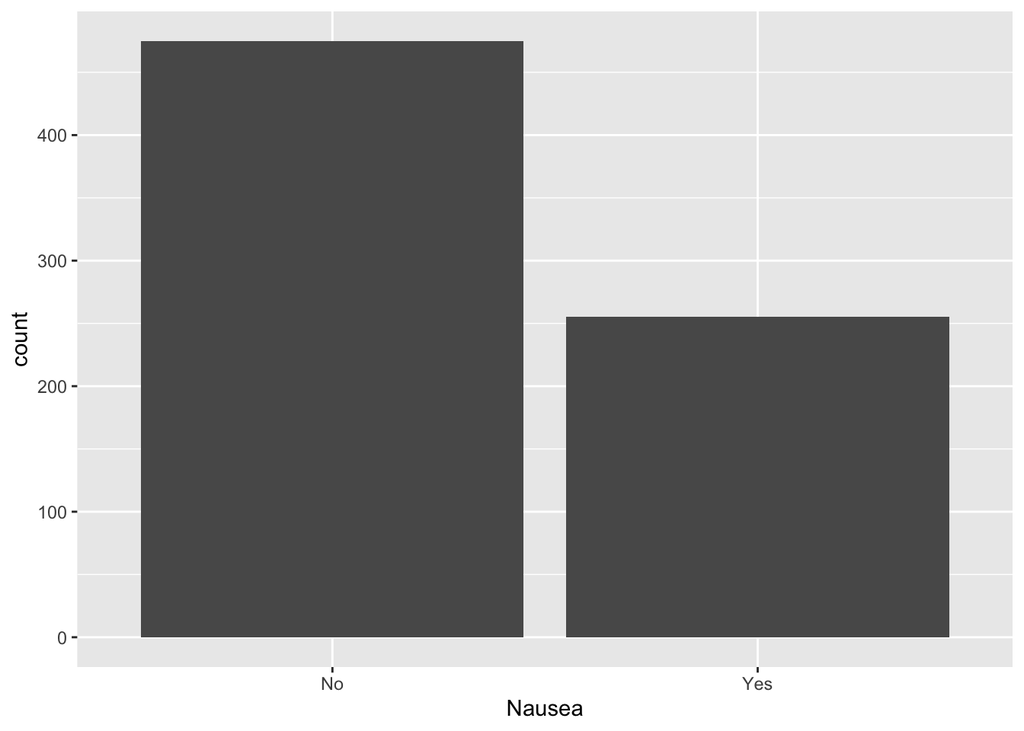

```r
nauseabarplot <- data %>% ggplot(aes(Nausea)) + geom_bar()
#view plot
nauseabarplot
```

```r
#save plot
saveRDS(nauseabarplot, file = here("results", "EDA", "nauseabarplot.rds"))
```

### plots for outcomes vs predictors

##Plots for body temperature

#BodyTemp and nausea

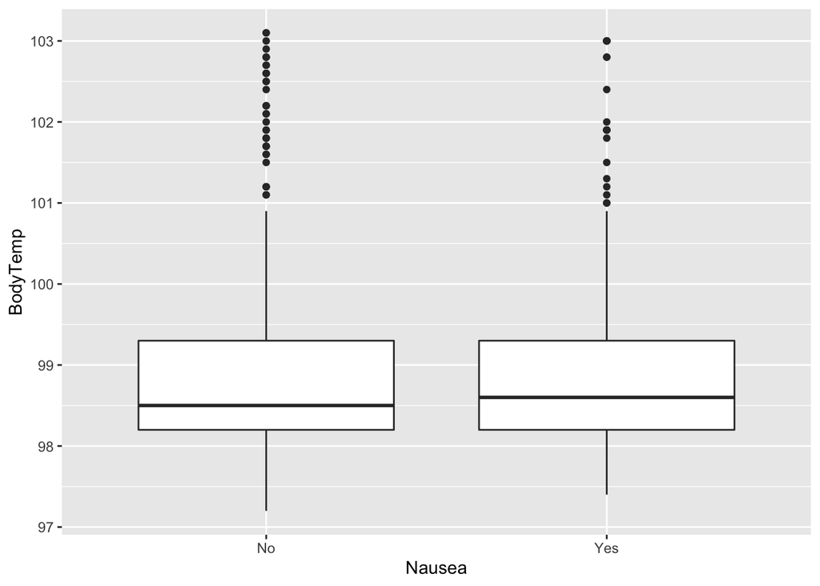

```r
data %>% ggplot(aes(Nausea, BodyTemp)) + geom_boxplot()
```

Here, we are looking to see how our outcomes of interest relate to each other. Cases with Nausea are shifted slightly updwards for BodyTemp, but only equivalent to <0.25 degrees F.

Let’s look at some other predictors for our main outcomes.

# BodyTemp and RunnyNose

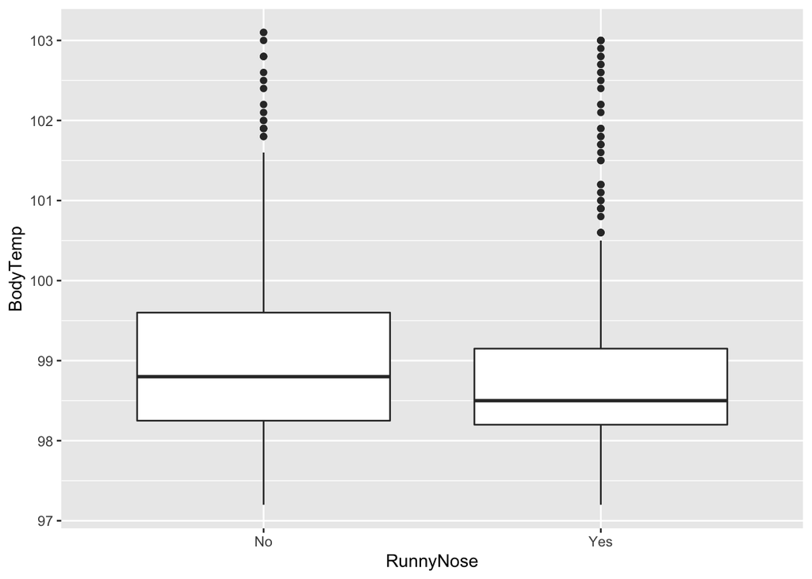

```r
data %>% ggplot(aes(RunnyNose, BodyTemp)) + geom_boxplot()
```

Body temperature appears to decrease in cases of runny nose.

# BodyTemp and fatigue

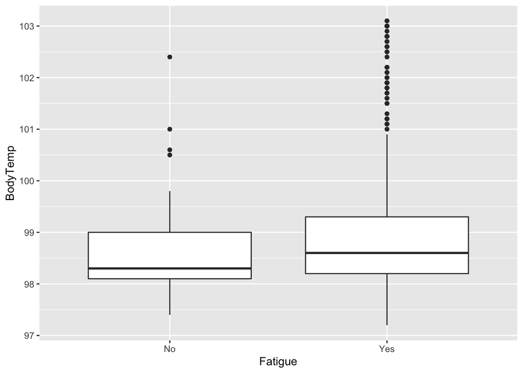

```r
data %>% ggplot(aes(Fatigue, BodyTemp)) + geom_boxplot()
```

This figure shows that individuals experiencing fatigue had higher body temperatures than those not experiencing fatigue.

# Body temperature and swollen lymph nodes

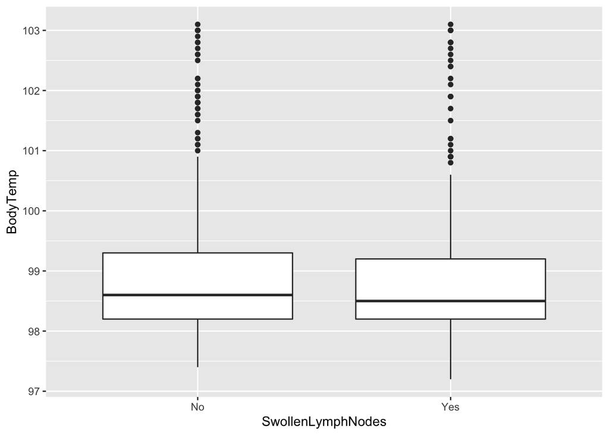

```r
data %>% ggplot(aes(SwollenLymphNodes, BodyTemp)) + geom_boxplot()
```

There isn’t a clear difference in Body Temp for cases experiencing swollen lymph nodes versus not.

#body temp and chills/sweats

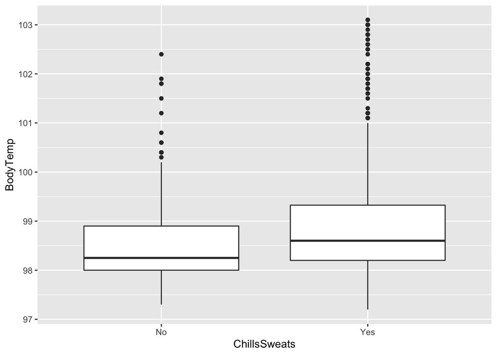

```r
data %>% ggplot(aes(ChillsSweats, BodyTemp)) + geom_boxplot()
```

This figure shows that individuals experiencing chills/sweats had higher body temperatures than those not experiencing chills/sweats. Based on these preliminary figures, my predictors of interest for BodyTemp could be **ChillsSweats** and **Fatigue**.

Next, let’s look at Nausea. The data visualization cheat sheet suggests `geom_count` for comparing two categorical variables. We’ll see what that looks like. With these plots, we’re looking for yes/yes cases to have the largest frequency - that would help us narrow down what might be a predictor of Nausea.

##Plots for nausea

# Nausea and fatigue

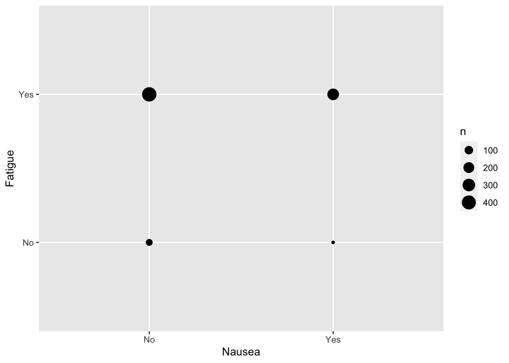

```r
data %>% ggplot(aes(Nausea, Fatigue)) + geom_count()
```

There are more cases of fatigue and no nausea, than of fatigue and nausea.

# Nausea and swollen lymph nodes

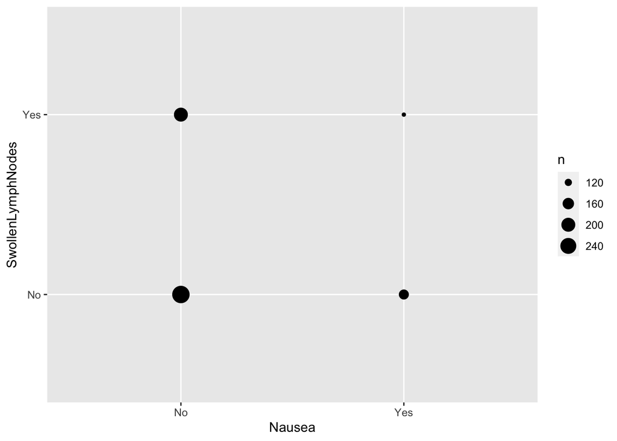

```r
data %>% ggplot(aes(Nausea, SwollenLymphNodes)) + geom_count()
```

# Nausea and chills/sweats

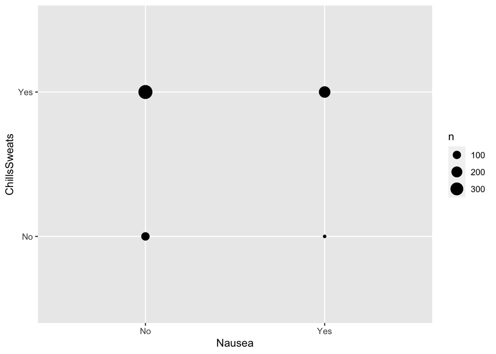

```r
data %>% ggplot(aes(Nausea, ChillsSweats)) + geom_count()
```

There aren’t any super clear assocations between nausea and the other predictors we have explored so far (clear association = significantly different counts of yes/yes observations vs yes/no or no/no). Let’s look at headache and abdominal pain before moving on.

# Nausea and headache

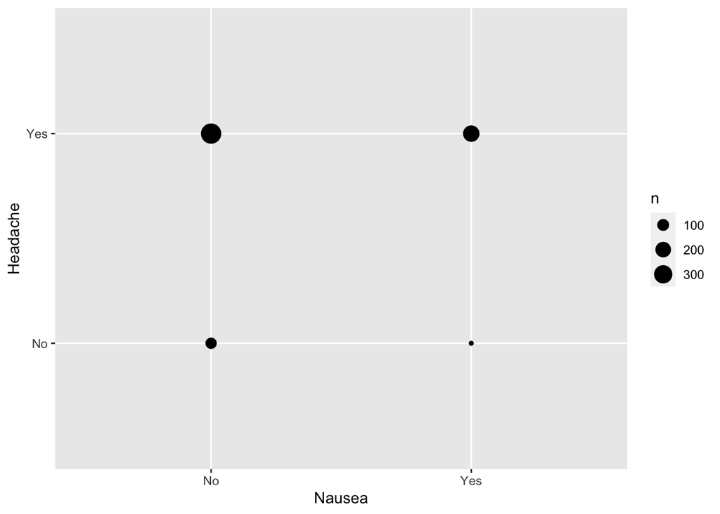

```r
data %>% ggplot(aes(Nausea, Headache)) + geom_count()
```

It looks like the most frequent pairing of observations is yes/headache and no/nausea, but I can’t tell from this figure how different that association is from the yes/headache and yes/nausea observations.

# Nausea and abdominal pain

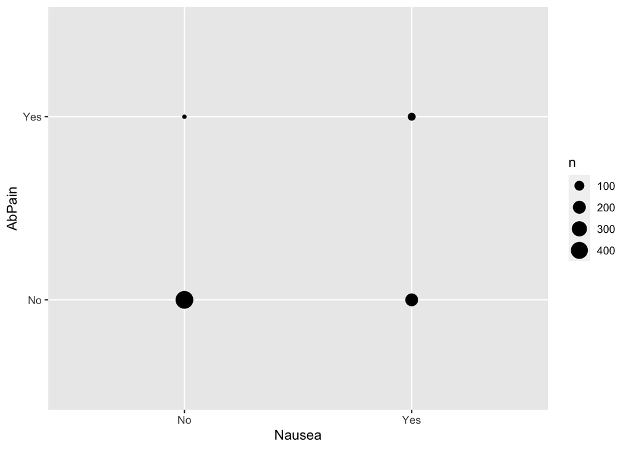

```r
data %>% ggplot(aes(Nausea, AbPain)) + geom_count()
```

This figure shows what is probably the most noticable association, but since the association is for no/no responses, this may not be very informative for modeling our data. We can check out a few more variables to see if there are assocations.

# Nausea and chest congestion

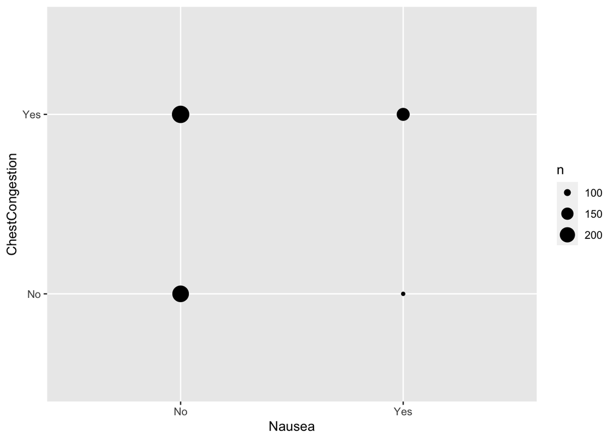

```r
data %>% ggplot(aes(Nausea, ChestCongestion)) + geom_count()
```

There are some cases of nausea and chest congestion, but at a lower frequency than cases of no/no or yes/chest congestion and no/nausea.

#Nausea and ChestCongestion

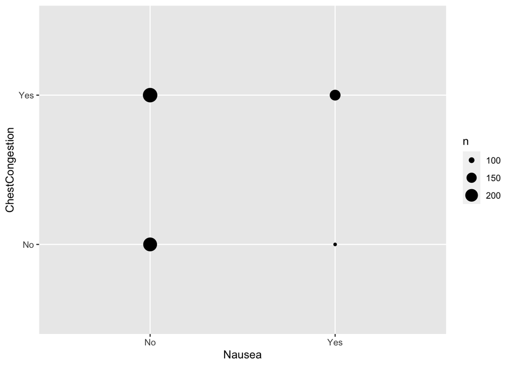

```r
data %>% ggplot(aes(Nausea, ChestCongestion)) + geom_count()
```

#Nausea and runny nose

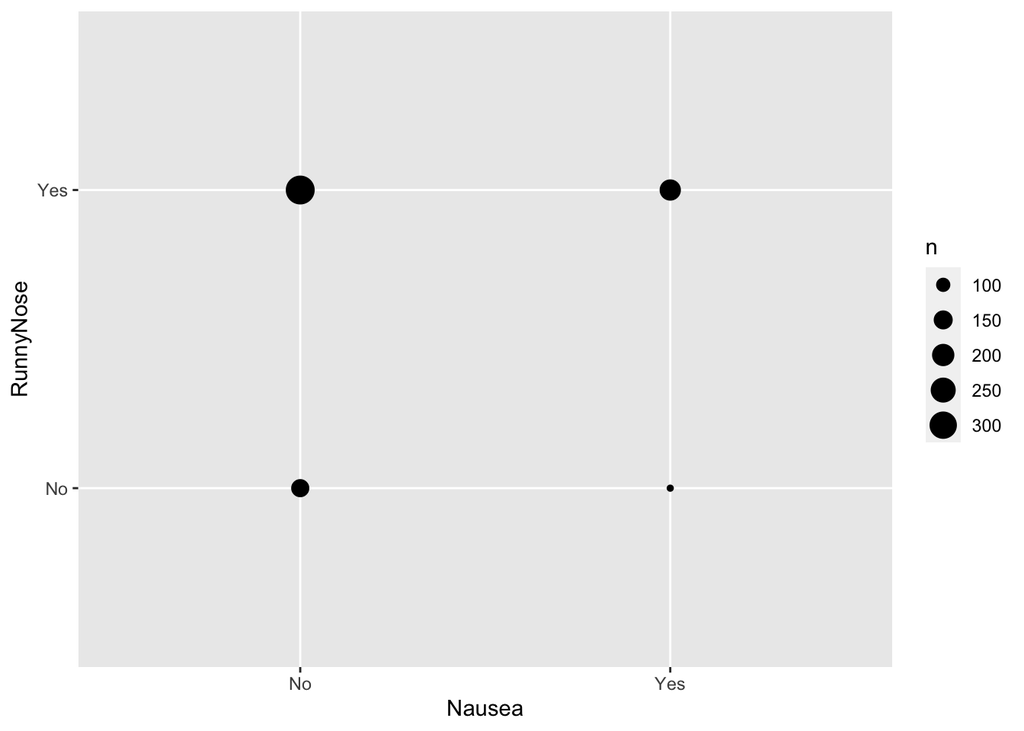

```r
data %>% ggplot(aes(Nausea, RunnyNose)) + geom_count()
```

This figure shows the most cases of yes/runnynose and no/nausea.

Based on this exploration, **ChillsSweats** and **Fatigue** might be predictors of body temperature, while I am unsure of which predictors will be suitable for cases of nausea. The figures that I looked at showed some associations, but I am unsure if they are strong enough associations for our modeling exericise, or if the associations themselves are informative enough.

For now, my exploration did not lead me to do any additional cleaning, so no additional cleaned data file needs to be saved at this point. I could potentially remove some variables to create a smaller, streamlined dataset, but I think that some symptom variables may be useful during the modeling portion (even if I don’t realize it yet).